# MTH6139 Time Series

Coursework 1 – Template

Gurjeevan Chahal

Spring term 2025

**Introduction** This project analyses and forecasts the stock price of Meta (formerly Facebook) from January 2013 to December 2024 using Meta’s Prophet forecasting model. Studying trends, seasonality, and projected future prices are the objectives. For deeper understanding, I also use interactive visualisations, test for heteroscedasticity, and apply linear regression.

```r
# Load libraries
library(prophet)
library(quantmod)
library(zoo)
library(lmtest)
library(car)
library(plotly)
library(MASS)
```

**Data Import & Preparation**

```r
# Importing Meta stock data
meta <- getSymbols('META', from='2013-01-01', to='2024-12-31', auto.assign = FALSE)

# Converting to data frame
meta_df <- data.frame(
  Date = index(meta),   # Date column
  Close = Cl(meta)        # Closing price as target variable
)

meta_df <- data.frame(ds = meta_df$Date, y = meta_df$META.Close)
```

Cl(meta) gives the closing stock price for Meta on each trading day. The values represent the price at which Meta’s stock closed at the end of each trading session.

```r
#Data Summary
summary(meta_df)
```

```
##        ds                   y
##  Min.   :2013-01-02   Min.   : 22.9
##  1st Qu.:2015-12-30   1st Qu.:104.2
##  Median :2018-12-31   Median :170.2
##  Mean   :2018-12-30   Mean   :193.7
##  3rd Qu.:2021-12-28   3rd Qu.:259.4
##  Max.   :2024-12-30   Max.   :632.7
```

```r
str(meta_df)
```

```
## 'data.frame':    3019 obs. of  2 variables:
##  $ ds: Date, format: "2013-01-02" "2013-01-03" ...
##  $ y : num  28 27.8 28.8 29.4 29.1 ...
```

```r
head(meta_df)
```

```
##           ds     y
## 1 2013-01-02 28.00
## 2 2013-01-03 27.77
## 3 2013-01-04 28.76
## 4 2013-01-07 29.42
## 5 2013-01-08 29.06
## 6 2013-01-09 30.59
```

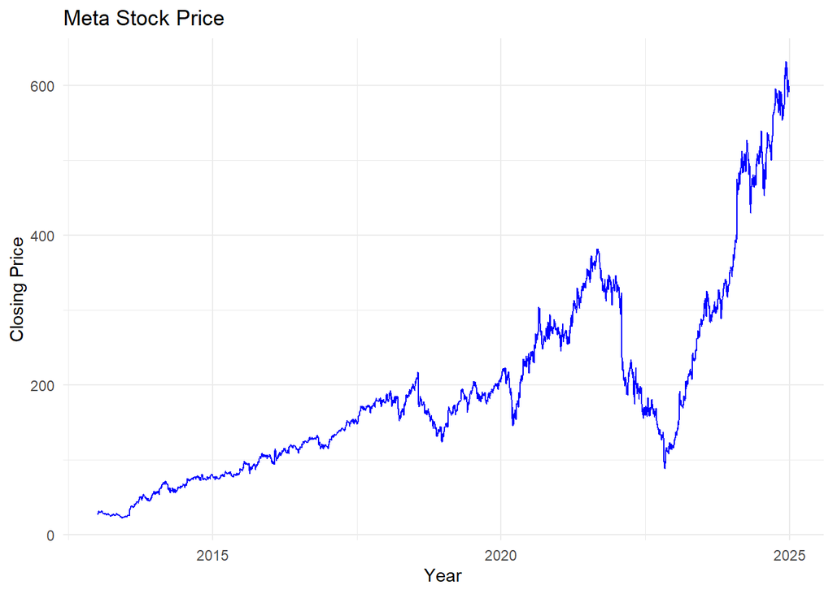

```r
# Visualising initial stock data
ggplot(meta_df, aes(x = ds, y = y)) +
  geom_line(color = "blue") +
  labs(title = "Meta Stock Price", x = "Year", y = "Closing Price") +
  theme_minimal()
```

Meta’s stock price has been rising steadily over the long run, with sporadic corrections. The significant rise in 2024–2025 points to improved business performance and rekindled investor confidence. Stock prices, however, have historically fluctuated, so investors should take market trends into account before making decisions.

**Prophet Forecasting Model**

Train Prophet Model

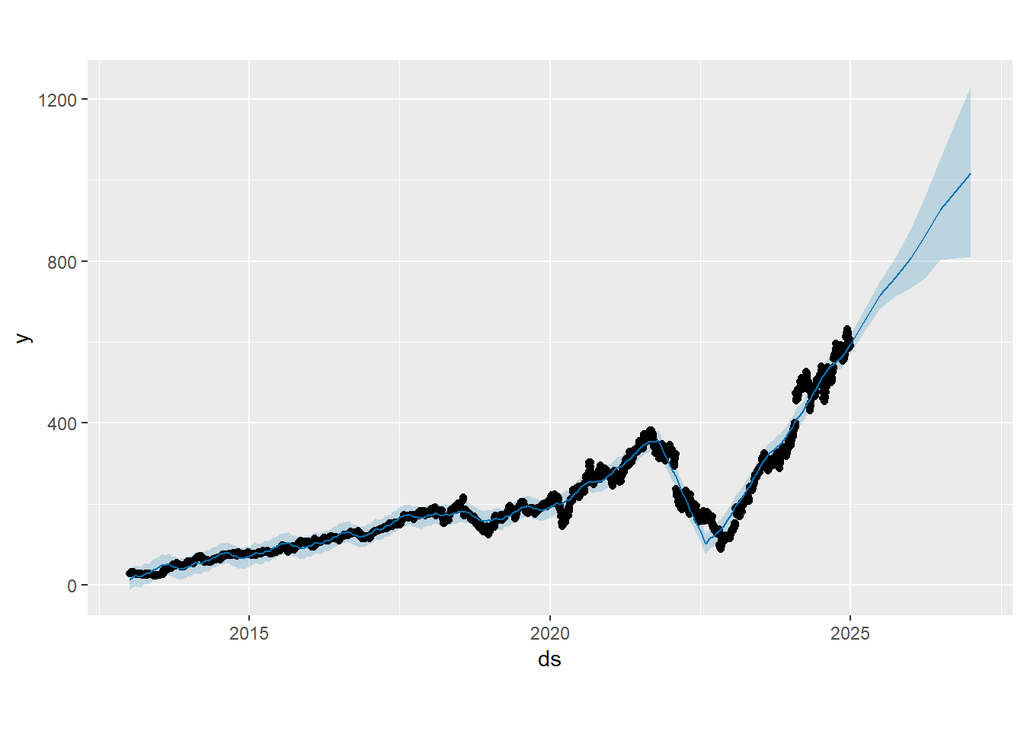

```r
m <- prophet::prophet(meta_df)
f <- prophet::make_future_dataframe(m, periods=8, freq="quarter")
p <- predict(m, f)
plot(m,p)
```

The price of Meta’s stock is expected to rise significantly over the next eight quarters, possibly reaching $1200 USD by the end of 2026. After a prior strong recovery, the forecast indicates further growth. The growing confidence interval, however, indicates that uncertainty is growing over time. The model forecasts sustained positive momentum, despite historical data indicating periods of high volatility. Although the trend is positive, investors should be mindful that outside variables like market sentiment and macroeconomic conditions may have an impact on actual performance.

**Trend & Seasonality Analysis**

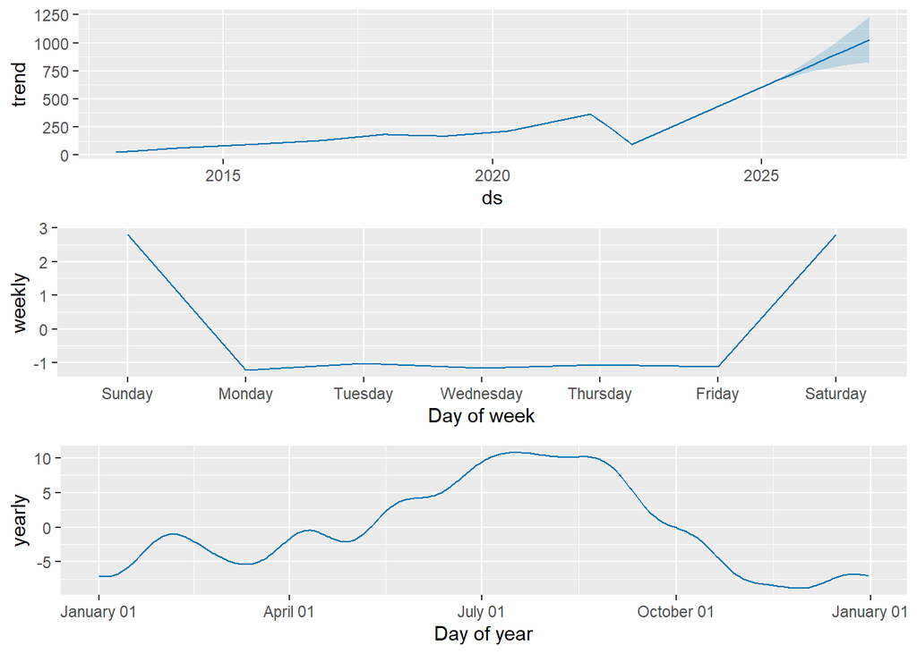

```r
prophet_plot_components(m, p)
```

**Linear Regression Analysis**

```r
linear_model <- lm(y ~ as.numeric(ds), data = meta_df)
summary(linear_model)
```

```
##
## Call:
## lm(formula = y ~ as.numeric(ds), data = meta_df)
##
## Residuals:
##      Min       1Q   Median       3Q      Max
## -224.201  -21.932    4.821   17.384  254.158
##
## Coefficients:
##                  Estimate Std. Error t value Pr(>|t|)
## (Intercept)    -1.328e+03  1.789e+01  -74.24   <2e-16 ***
## as.numeric(ds)  8.506e-02  9.974e-04   85.28   <2e-16 ***
## ---
## Signif. codes:  0 '***' 0.001 '**' 0.01 '*' 0.05 '.' 0.1 ' ' 1
##
## Residual standard error: 69.31 on 3017 degrees of freedom
## Multiple R-squared:  0.7068, Adjusted R-squared:  0.7067
## F-statistic:  7273 on 1 and 3017 DF,  p-value: < 2.2e-16
```

According to the linear regression model, stock prices have been rising steadily over time. According to the time coefficient (0.0851), the stock price rises by about 0.085 units every day on average. This implies that the stock value will increase steadily over time. There is a strong correlation between time and stock price, as evidenced by the R-squared value of 0.7068, which shows that this linear trend accounts for roughly 70.7% of the variation in stock prices. The statistical significance of this trend is confirmed by the extremely low p-value (<2.2e-16).

**Check Residuals**

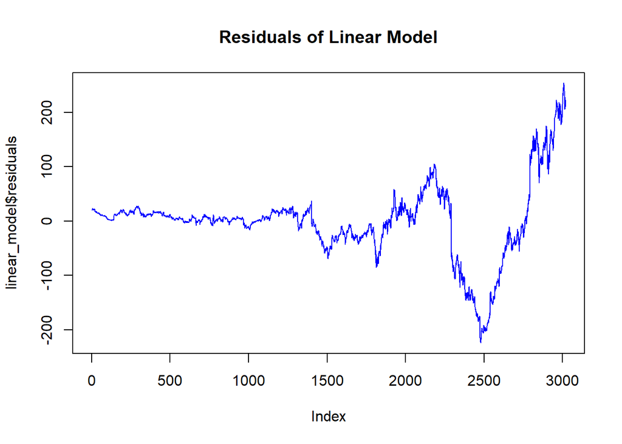

```r
plot(linear_model$residuals, main="Residuals of Linear Model", col="blue", type="l")
```

However, the residual plot suggests that actual stock prices experience fluctuations beyond the linear trend, likely due to external market factors.

**Heteroscedasticity Test (Breusch-Pagan Test)**

```r
bptest(linear_model)
```

```
##
##  studentized Breusch-Pagan test
##
## data:  linear_model
## BP = 1020.1, df = 1, p-value < 2.2e-16
```

This finding implies that the model has heteroscedasticity, which means that the residuals’ variance varies over time. This may affect how reliable confidence intervals and standard errors are.

**Variance Stabilization (Box-Cox Transformation)**

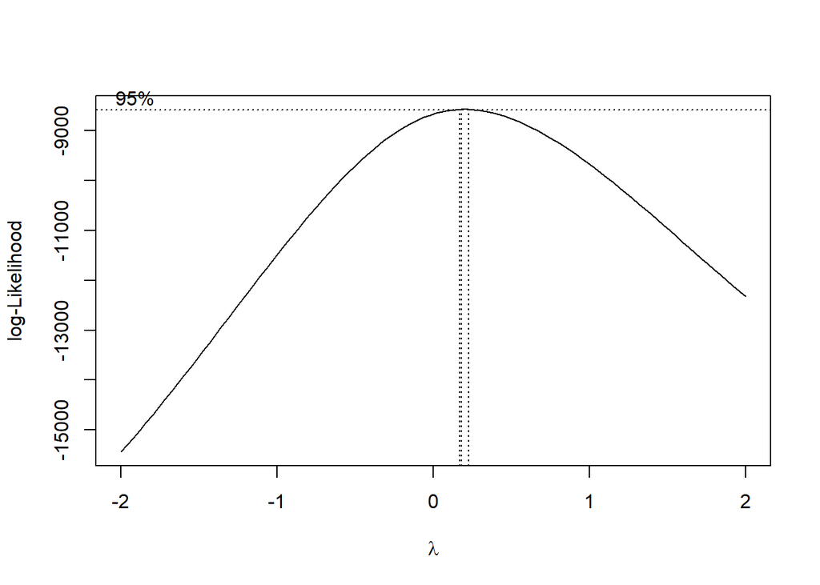

```r
boxcox(linear_model, lambda = seq(-2, 2))
```

**Applying the transformation to stabilize the variance**

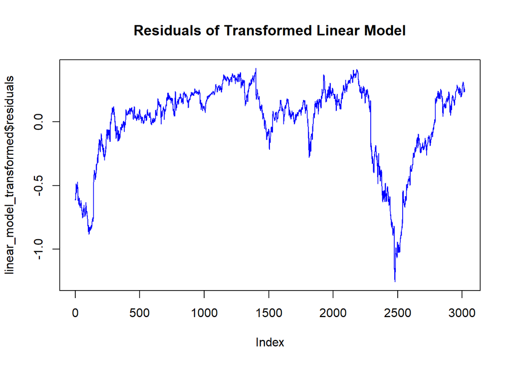

```r
# Applying the log transformation
meta_df$y_transformed <- log(meta_df$y)

# Fitting a new linear model with transformed response variable
linear_model_transformed <- lm(y_transformed ~ as.numeric(ds), data = meta_df)


plot(linear_model_transformed$residuals, main="Residuals of Transformed Linear Model", col="blue", type="l")
```

After transforming the variance seems stabilize a little bit though still there exist little variability.